# Análise sobre séries de TV

Mainara Cavalcanti de Farias

3 de maio de 2018

```r
series = read_csv(here("data/series_from_imdb.csv"),
                    progress = FALSE,
                    col_types = cols(.default = col_double(),
                                     series_name = col_character(),
                                     episode = col_character(),
                                     url = col_character(),
                                     season = col_character()))
```

O objetivo dessa análise é avaliar séries de TV com relação ao seu gênero e qualidade. Serão utilizados dados de 511 séries que foram retirados do IMDb.

### Qual o gênero mais recorrente dentre as 10 séries mais bem avaliadas? E entre as 10 com piores avaliações?

Para chegarmos ao resultado que desejamos teremos que saber quais são as séries mais bem avaliadas e quais as com piores avaliações, então vamos primeiro fazer a mediana das avaliações das temporadas de cada série, e por fim, a média dessas temporadas, dessa forma poderemos classificar as séries quanto a sua avaliação.

```r
medias = series %>%
    group_by(series_name, season) %>%
    summarise(mediana = median(user_rating)) %>%
    group_by(series_name) %>%
    summarise(media = mean(mediana)) %>%
    arrange(media)
medias
```

| series_name | media |
| --- | --- |
| American Idol | 5.006667 |
| Bionic Woman | 5.100000 |
| Work It | 5.900000 |
| Free Agents | 6.100000 |
| Bouquet Of Barbed Wire | 6.200000 |
| Hamarinn (The Cliff) | 6.200000 |
| Steven Seagal: Lawman | 6.200000 |
| Cupid | 6.300000 |
| Yu Yu Hakusho | 6.300000 |
| How To Live With Your Parents | 6.400000 |

[output cut: 501 more lines]

Agora que temos a média das avaliações de cada série, podemos descobrir quais as 10 mais bem avaliadas e as 10 com piores avaliações.

**As 10 séries com piores avaliações:**

```r
piores_series = head(medias, 10)
names(piores_series)[1] <- "Nome da Série"
names(piores_series)[2] <- "Média"
piores_series
```

| Nome da Série | Média |
| --- | --- |
| American Idol | 5.006667 |
| Bionic Woman | 5.100000 |
| Work It | 5.900000 |
| Free Agents | 6.100000 |
| Bouquet Of Barbed Wire | 6.200000 |
| Hamarinn (The Cliff) | 6.200000 |
| Steven Seagal: Lawman | 6.200000 |
| Cupid | 6.300000 |
| Yu Yu Hakusho | 6.300000 |
| How To Live With Your Parents | 6.400000 |

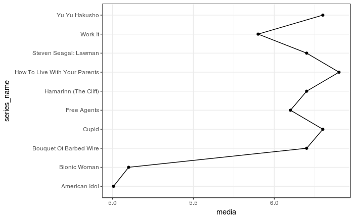

```r
ggplot(data = piores_series, aes(x = series_name, y = media, group = 1))+
     geom_line() +
     geom_point() +
    coord_flip()
```

**As 10 séries com melhores avaliações:**

```r
melhores_series = tail(medias, 10)
names(melhores_series)[1] <- "Nome da Série"
names(melhores_series)[2] <- "Média"
melhores_series
```

| Nome da Série | Média |
| --- | --- |
| Stranger Things | 8.950000 |
| Turn | 8.966667 |
| Game of Thrones | 8.983333 |
| Sherlock | 8.987500 |
| Daredevil | 9.000000 |
| Fargo | 9.000000 |
| Super Girl | 9.000000 |
| The Leftovers | 9.016667 |
| The Originals | 9.025000 |
| Person Of Interest | 9.200000 |

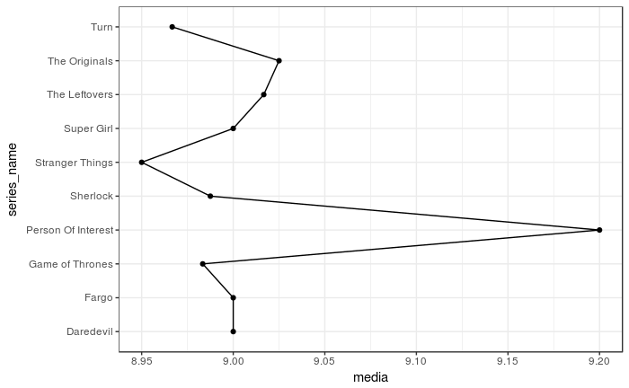

```r
ggplot(data = melhores_series, aes(x = series_name, y = media, group = 1))+
     geom_line() +
     geom_point() +
    coord_flip()
```

Já que as séries estão classificadas, vamos adicionar o gênero de cada uma.

```r
genero_piores_series = piores_series %>%
    mutate(Genero = case_when(series_name == "American Idol" ~ "Reality Show",
                              series_name == "Bionic Woman" ~ "Ficção Científica",
                              series_name == "Work It" ~ "Comédia",
                              series_name == "Free Agents" ~ "Comédia",
                              series_name == "Bouquet Of Barbed Wire" ~ "Drama",
                              series_name == "Hamarinn (The Cliff)" ~ "Drama",
                              series_name == "Steven Seagal: Lawman" ~ "Reality Show",
                              series_name == "Cupid" ~ "Drama",
                              series_name == "Yu Yu Hakusho" ~ "Ação",
                              series_name == "How To Live With Your Parents" ~ "Comédia"))
genero_melhores_series = melhores_series %>%
    mutate(Genero = case_when(series_name == "Person Of Interest" ~ "Drama",
                              series_name == "The Originals" ~ "Drama",
                              series_name == "The Leftovers" ~ "Drama",
                              series_name == "Super Girl" ~ "Super-herói",
                              series_name == "Fargo" ~ "Humor negro",
                              series_name == "Daredevil" ~ "Drama",
                              series_name == "Sherlock" ~ "Aventura",
                              series_name == "Game of Thrones" ~ "Fantasia",
                              series_name == "Turn" ~ "Drama",
                              series_name == "Stranger Things" ~ "Fantasia"))
```

E por fim, vamos verificar o gêneros mais recorrente nos dois conjuntos de dados.  
**Gênero(s) mais frequentes nas piores séries:**

```
Ignoring unknown parameters: binwidth, bins, pad
```

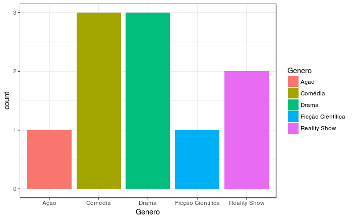

```r
ggplot(data = genero_piores_series, aes(x = Genero,  fill = Genero)) +
    geom_histogram(stat = 'count')
```

Ou seja, comédia e drama são os gêneros mais frequentes, porém acredito que há mais séries de drama no geral, por isso há mais chance de estar presente nesse resultado.

**Gênero(s) mais frequentes nas melhores séries:**

```
Ignoring unknown parameters: binwidth, bins, pad
```

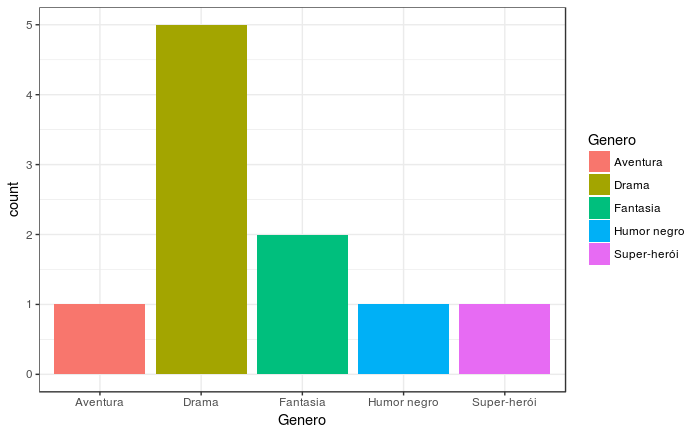

```r
ggplot(data = genero_melhores_series, aes(x = Genero,  fill = Genero)) +
    geom_histogram(stat = 'count')
```

Nesse caso, metade das séries mais bem avaliadas são do gênero drama e apesar de ter dito anteriormente que acredito que há mais séries desse gênero e por esse motivo existir mais chances dele aparecer nessa resposta, imagino que esse resultado reflita a realidade.